# EDA Deal_with_Outliers_data

```python
import numpy as np
import pandas as pd
import seaborn as sns
import matplotlib.pyplot as plt
```

```python
visa_df=pd.read_csv('Visadataset.csv')
visa_df
```

|  | case_id | continent | education_of_employee | has_job_experience | requires_job_training | no_of_employees | yr_of_estab | region_of_employment | prevailing_wage | unit_of_wage | full_time_position | case_status |
| --- | --- | --- | --- | --- | --- | --- | --- | --- | --- | --- | --- | --- |
| 0 | EZYV01 | Asia | High School | N | N | 14513 | 2007 | West | 592.2029 | Hour | Y | Denied |
| 1 | EZYV02 | Asia | Master's | Y | N | 2412 | 2002 | Northeast | 83425.6500 | Year | Y | Certified |
| 2 | EZYV03 | Asia | Bachelor's | N | Y | 44444 | 2008 | West | 122996.8600 | Year | Y | Denied |
| 3 | EZYV04 | Asia | Bachelor's | N | N | 98 | 1897 | West | 83434.0300 | Year | Y | Denied |
| 4 | EZYV05 | Africa | Master's | Y | N | 1082 | 2005 | South | 149907.3900 | Year | Y | Certified |
| ... | ... | ... | ... | ... | ... | ... | ... | ... | ... | ... | ... | ... |
| 25475 | EZYV25476 | Asia | Bachelor's | Y | Y | 2601 | 2008 | South | 77092.5700 | Year | Y | Certified |
| 25476 | EZYV25477 | Asia | High School | Y | N | 3274 | 2006 | Northeast | 279174.7900 | Year | Y | Certified |
| 25477 | EZYV25478 | Asia | Master's | Y | N | 1121 | 1910 | South | 146298.8500 | Year | N | Certified |
| 25478 | EZYV25479 | Asia | Master's | Y | Y | 1918 | 1887 | West | 86154.7700 | Year | Y | Certified |
| 25479 | EZYV25480 | Asia | Bachelor's | Y | N | 3195 | 1960 | Midwest | 70876.9100 | Year | Y | Certified |

25480 rows × 12 columns

# Categorical columns and Numerical columns

```python
cat_cols=visa_df.select_dtypes(include='object').columns
num_cols=visa_df.select_dtypes(exclude='object').columns

cat_cols, num_cols
```

```
(Index(['case_id', 'continent', 'education_of_employee', 'has_job_experience',
        'requires_job_training', 'region_of_employment', 'unit_of_wage',
        'full_time_position', 'case_status'],
       dtype='object'),
 Index(['no_of_employees', 'yr_of_estab', 'prevailing_wage'], dtype='object'))
```

# Calculate Non-Outliers data

```python
wage_data=visa_df['prevailing_wage']
q1=round(np.quantile(wage_data,0.25),2)
q2=round(np.quantile(wage_data,0.50),2)
q3=round(np.quantile(wage_data,0.75),2)

iqr=q3-q1

lb=q1-1.5*iqr
ub=q3+1.5*iqr

con1=wage_data>lb
con2=wage_data<ub

con=con1&con2
non_outliers_data=visa_df[con]
non_outliers_data
```

|  | case_id | continent | education_of_employee | has_job_experience | requires_job_training | no_of_employees | yr_of_estab | region_of_employment | prevailing_wage | unit_of_wage | full_time_position | case_status |
| --- | --- | --- | --- | --- | --- | --- | --- | --- | --- | --- | --- | --- |
| 0 | EZYV01 | Asia | High School | N | N | 14513 | 2007 | West | 592.2029 | Hour | Y | Denied |
| 1 | EZYV02 | Asia | Master's | Y | N | 2412 | 2002 | Northeast | 83425.6500 | Year | Y | Certified |
| 2 | EZYV03 | Asia | Bachelor's | N | Y | 44444 | 2008 | West | 122996.8600 | Year | Y | Denied |
| 3 | EZYV04 | Asia | Bachelor's | N | N | 98 | 1897 | West | 83434.0300 | Year | Y | Denied |
| 4 | EZYV05 | Africa | Master's | Y | N | 1082 | 2005 | South | 149907.3900 | Year | Y | Certified |
| ... | ... | ... | ... | ... | ... | ... | ... | ... | ... | ... | ... | ... |
| 25474 | EZYV25475 | Africa | Doctorate | N | N | 2594 | 1979 | Northeast | 51104.7800 | Year | Y | Certified |
| 25475 | EZYV25476 | Asia | Bachelor's | Y | Y | 2601 | 2008 | South | 77092.5700 | Year | Y | Certified |
| 25477 | EZYV25478 | Asia | Master's | Y | N | 1121 | 1910 | South | 146298.8500 | Year | N | Certified |
| 25478 | EZYV25479 | Asia | Master's | Y | Y | 1918 | 1887 | West | 86154.7700 | Year | Y | Certified |
| 25479 | EZYV25480 | Asia | Bachelor's | Y | N | 3195 | 1960 | Midwest | 70876.9100 | Year | Y | Certified |

25053 rows × 12 columns

# Calculate Outliers_data

```python
wage_data=visa_df['prevailing_wage'] # take one num col which is having outliers

q1=round(np.quantile(wage_data,0.25),2)  # calculate Q1 (25 percentile)
q2=round(np.quantile(wage_data,0.50),2)  # calculate Q2 (50 percentile)
q3=round(np.quantile(wage_data,0.75),2)  # calculate Q3 (75 percentile)

iqr=q3-q1  # calculate IQR

lb=q1-1.5*iqr  # Lower bound
ub=q3+1.5*iqr # upper bound

con1=wage_data<lb   # condition 1
con2=wage_data>ub   # condition 2

con3=con1|con2    # condition 3
outliers_data=visa_df[con3]   # True False value converted into data frame
outliers_data
```

|  | case_id | continent | education_of_employee | has_job_experience | requires_job_training | no_of_employees | yr_of_estab | region_of_employment | prevailing_wage | unit_of_wage | full_time_position | case_status |
| --- | --- | --- | --- | --- | --- | --- | --- | --- | --- | --- | --- | --- |
| 14 | EZYV15 | Asia | Master's | Y | Y | 15756 | 2006 | South | 220081.73 | Year | Y | Certified |
| 34 | EZYV35 | Asia | Master's | N | N | 1809 | 2010 | South | 225569.73 | Year | N | Certified |
| 130 | EZYV131 | South America | High School | N | N | 2554 | 2005 | Midwest | 247393.01 | Year | Y | Certified |
| 216 | EZYV217 | Asia | Master's | Y | N | 1515 | 2001 | Midwest | 269321.68 | Year | N | Certified |
| 221 | EZYV222 | North America | Doctorate | Y | Y | 2518 | 2010 | South | 219529.62 | Year | Y | Certified |
| ... | ... | ... | ... | ... | ... | ... | ... | ... | ... | ... | ... | ... |
| 25191 | EZYV25192 | Asia | Master's | N | N | 4983 | 2005 | Midwest | 280482.51 | Year | Y | Denied |
| 25195 | EZYV25196 | North America | Master's | Y | N | 47 | 2001 | South | 234308.77 | Year | N | Certified |
| 25468 | EZYV25469 | Asia | Bachelor's | N | N | 373 | 2005 | Midwest | 272715.74 | Year | N | Certified |
| 25469 | EZYV25470 | North America | Master's | Y | N | 2261 | 1997 | Northeast | 273772.47 | Year | N | Certified |
| 25476 | EZYV25477 | Asia | High School | Y | N | 3274 | 2006 | Northeast | 279174.79 | Year | Y | Certified |

427 rows × 12 columns

# Ploting outliers and non_outliers data

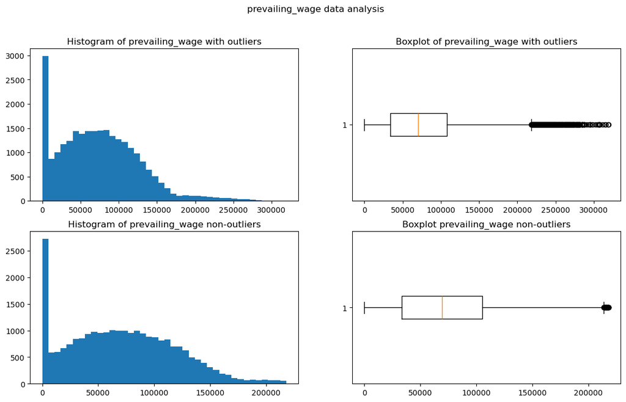

```python
plt.figure(figsize=(14,8))
plt.suptitle('prevailing_wage data analysis')

plt.subplot(2,2,1).hist(visa_df['prevailing_wage'],bins=40)
plt.title('Histogram of prevailing_wage with outliers')

plt.subplot(2,2,2).boxplot(visa_df['prevailing_wage'],vert=False)
plt.title('Boxplot of prevailing_wage with outliers')

plt.subplot(2,2,3).hist(non_outliers_data['prevailing_wage'],bins=40)
plt.title('Histogram of prevailing_wage non-outliers')

plt.subplot(2,2,4).boxplot(non_outliers_data['prevailing_wage'],vert=False)
plt.title('Boxplot prevailing_wage non-outliers')

plt.show()
```

# How to deal the outliers

**Method-1: Drop the outliers**

- if outliers has less than 2% of total data, we can drop the outliers
- drop the outliers is not a recommended approch
- if we drop the outliers other values also drop
- we encounter a situation about to loss the data
- in above we developed a code for **non-outliers data**

**Method-2: Fill with Median**

- we already know that outliers does not affect by median
- so it is a good approch fill the outliers with median

**Method-3: Cap the outliers**

- instead of fill the outliers with median, we can fill with **Q3** or **Q1** or **max** or **min** value

# fill the outliers with median using python scratch

```python
wage_data=visa_df['prevailing_wage']

q1=round(np.quantile(wage_data,0.25),2)
q2=round(np.quantile(wage_data,0.50),2)
q3=round(np.quantile(wage_data,0.75),2)

iqr=q3-q1

lb=q1-1.5*iqr
ub=q3+1.5*iqr

median=wage_data.median()

new_data=[]
for val in wage_data:
    if val<lb or val>ub:
        new_data.append(median)

    else:
        new_data.append(val)

visa_df['prevailing_wage']=new_data
```

```python
visa_df['prevailing_wage']
```

```
0           592.2029
1         83425.6500
2        122996.8600
3         83434.0300
4        149907.3900
            ...
25475     77092.5700
25476     70308.2100
25477    146298.8500
25478     86154.7700
25479     70876.9100
Name: prevailing_wage, Length: 25480, dtype: float64
```

```python
np.max(visa_df['prevailing_wage'])
```

```
218094.61
```

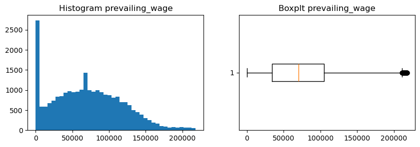

```python
wage_data=visa_df['prevailing_wage']
plt.suptitle('prevailing_wage data analysis')

plt.figure(figsize=(10,3))

plt.subplot(1,2,1).hist(wage_data, bins=40)
plt.title('Histogram prevailing_wage')

plt.subplot(1,2,2).boxplot(wage_data, vert=False)
plt.title('Boxplt prevailing_wage')

plt.show()
```

# instead of 'for loop' and 'if condition' we use 'np.where'

# np.where

- np.where is a method useful when we can fill the values with one condition two outputs
- all the if-else statements we can do with np.where
- **syntax**: np.where(condition,True value,False value)
- it takes 3 arguments
  - Condition
  - True value: when the condition becomes True
  - False value: when the condition becomes False

```python
wage_data= visa_df['prevailing_wage']

q1=round(np.quantile(wage_data,0.25),2)
q2=round(np.quantile(wage_data,0.50),2)
q3=round(np.quantile(wage_data,0.75),2)

iqr=q3-q1

lb=q1-1.5*iqr
ub=q3+1.5*iqr

con1=wage_data<lb
con2=wage_data>ub
con=con1|con2

new_data = np.where(con, q2, wage_data)
visa_df['prevailing_wage'] = new_data
```

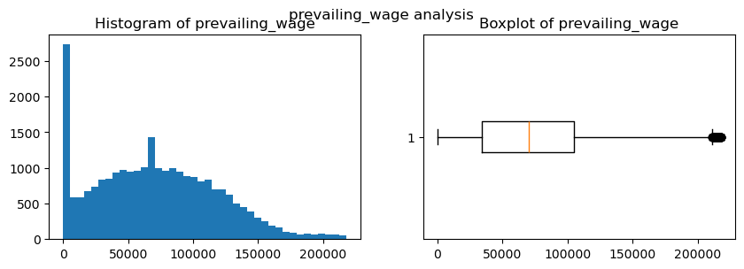

```python
plt.figure(figsize=(10,3))
plt.suptitle('prevailing_wage analysis')

plt.subplot(1,2,1).hist(visa_df['prevailing_wage'],bins=40)
plt.title('Histogram of prevailing_wage')

plt.subplot(1,2,2).boxplot(visa_df['prevailing_wage'],vert=False)
plt.title('Boxplot of prevailing_wage')

plt.show()
```